# Yelp Restaurant Reviews : Sentiment Analysis for the Prediction of Star Ratings

Kuan Siew Weng  
11 November 2015

### Can Review Text Sentiments Predict Star Ratings ?

- Restaurants are very interested to get more insights into the sentiments of their customers expressed on online review sites like Yelp.
- By itself, the star rating given in a Yelp review has limited value to the restaurants as there is no objective basis or reference.
- Strong sentiments are often expressed in Yelp review texts, which restaurants are keen to understand and leverage.
- Can text mining and machine learning methods be used to mine user sentiments in these review texts and to predict star ratings of the reviews?
- If so, how accurate are they?

1-star and 5-star Reviews Trigram WordClouds

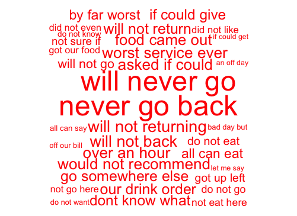

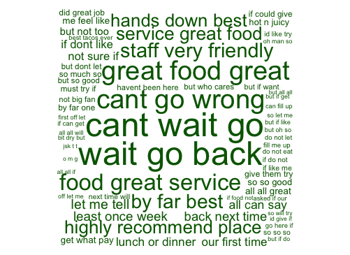

### Exploratory Data Analysis

- The data for this study are the restaurant reviews extracted from a 10% random sample of the Yelp Data Challenge 1.6M reviews dataset.
- 98841 user reviews for 15464 restaurants.
- Strong bias of reviewers to post positive reviews rather than negative reviews.
- Nearly 2 out of 3 restaurant reviews are rated 4 or 5 stars.
- Most reviews are less than 100 words long although a few reviews even exceeded 400 words.
- However, the length of the reviews does not appear to be correlated to their star ratings.

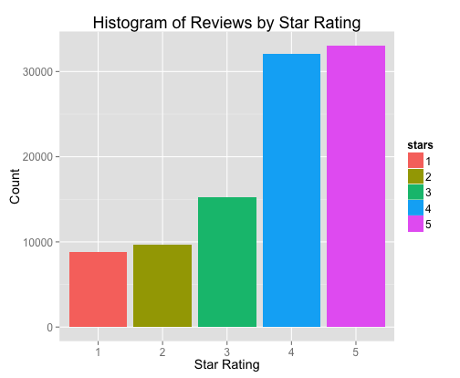

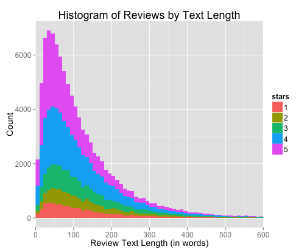

### Models and Methods

#### Sentiment Polarity Model

- We use the Sentiment Polarity Model from the **qdap** package
- The **polarity()** function analyzes a given text and returns a sentiment score between -1 and 1.
- A review-context-specific polarity dictionary associates sentiment weights to commonly used n-grams in the reviews.
- Sentiment polarity is analyzed at both sentence level and at whole-text level.

```r
polarity(sent_detect("This is worst place ever. Crap Food. Horrible service."), polarity.frame=REVIEWS_DICT, constrain=T)
```

```
  all total.sentences total.words ave.polarity sd.polarity stan.mean.polarity
1 all               3           9        -0.83       0.101             -8.225
```

#### Stars Rating Prediction Model

- The stars rating prediction model formula used is:

```r
stars ~ ave.polarity + tot.sentences + tot.words +
        pos.words.ct + neg.words.ct
```

- We use the **caret** package to partition the sample dataset (training: 70%, test: 30%);
- The model is fitted to the training dataset, using 3 classification methods with 3-fold cross-validation.
  1. Random Forest
  2. Naive-Bayes
  3. Penalized Multinomial Regression
- Finally, the 3 fitted models were tested with the unseen test dataset to produce the test results.

### Results and Discussion

#### Test Results Summary

- The highest accuracy (41%) was attained by the Penalized Multinomial Regression method.
- Overall Accuracy by Prediction Method

|  | RandomForest | NaiveBayes | Multinomial |
| --- | --- | --- | --- |
| Accuracy | 0.3893 | 0.3834 | 0.4141 |

- Multinomial - Prediction Accuracy by Class

|  | Class: 1 | Class: 2 | Class: 3 | Class: 4 | Class: 5 |
| --- | --- | --- | --- | --- | --- |
| Pos Pred Value | 0.4144 | 0.3049 | 0.2359 | 0.3525 | 0.4871 |
| Sensitivity | 0.5438 | 0.0886 | 0.0425 | 0.4228 | 0.6388 |
| Specificity | 0.9245 | 0.9780 | 0.9748 | 0.6280 | 0.6631 |

#### Test Results Discussion

- Overall stars prediction accuracy attained for all three methods are too low to be really useful.
- Low sensitivity scores means most 2 and 3 stars reviews were misclassified.
- Possible Reasons:
  1. One man's 2-stars is another man's 3-stars.
  2. Presence of positive words even in negative reviews.
  3. Use of slangs, swear words and sarcasm in reviews.
- Sentiment Class Prediction is more accurate (76%), if 4-5 stars are considered as one sentiment class, and 1-3 stars are considered as another sentiment class.  
  *(i.e. Thumbs-Up / Thumbs-Down Model)*